# Report_G_Group

Alberto Russo, Andrea Esposito, Barbara Loletti, Gabriel Masella, Ziyang Fu

2024-03-04

# Import the data

```r
# Define the current working directory
cwd <- getwd()

# Load the data
data <- read.csv(file.path(cwd, 'health_data.csv'))

# Display the first few rows of the data
head(data)
```

```
##   X id   age gender height weight ap_hi ap_lo cholesterol gluc smoke alco
## 1 0  0 18393      1    168     62   110    80           0    0     0    0
## 2 1  1 20228      0    156     85   140    90           2    0     0    0
## 3 2  2 18857      0    165     64   130    70           2    0     0    0
## 4 3  3 17623      1    169     82   150   100           0    0     0    0
## 5 4  4 17474      0    156     56   100    60           0    0     0    0
## 6 5  8 21914      0    151     67   120    80           1    1     0    0
##   active cardio
## 1      1      0
## 2      1      1
## 3      0      1
## 4      1      1
## 5      0      0
## 6      0      0
```

The data includes columns for the following variables:

- id: a unique identifier for each patient;
- an unnamed column as an index;
- age: the age of the patient in days;
- gender: a categorical feature for the sex of the patient, with 0 for “female” and 1 for “male”;
- height: height of patients in cm;
- weight: the weight of the patients in kg;
- ap_hi: systolic blood pressure, in mmHg;
- ap_lo: diastolic blood pressure, in mmHg;
- cholesterol: a categorical feature that codifies as 0 a normal level of cholesterol, 1 an above average level of cholesterol and with 2 a well above average level of cholesterol;
- gluc: a categorical feature that codifies as 0 a normal level of glucose, 1 an above average level of glucose and with 2 a well above average level of glucose;
- smoke: codifies whether the patient is a smoker or not;
- alco: codifies whether the patient is an habitual alcohol consumer;
- active: codifies whether the patient is physically active or not;
- cardio: the target variable, codifies whether the patient has been diagnosed with a cardiac disease.

It’s necessary to filter these columns by dropping the first two columns which are useless, converting the age from days into years, filtering for NaNs, Infs, eliminate absurd values (there are, for instance, negative pressure values, or values well above what’s physically possible, and some that are obvious input mistakes, but in a complicated way that would require edit by hand of each “wrong” value). A BMI column is added, since we expect height to be of little importance and the weight alone is insufficient to determine the body type of a person.

```r
# Create a working copy to avoid modifying the original data
df <- data

# Define the list of categorical variables
categorical <- c('gender', 'cholesterol', 'gluc', 'smoke', 'alco', 'active', 'cardio')

# Replace infinite values with NA in the entire data frame
df <- as.data.frame(lapply(df, function(x) replace(x, is.infinite(x), NA)))

# Remove NaNs, although according to the data description there are no NaNs
df <- na.omit(df)

# Drop the id column and -1
df <- df[, !(names(df) %in% c('id', 'X'))]

# Convert age in days
df$age <- df$age / 365.25

# Filter for impossible values for height, weight, ap_hi, ap_lo
df <- df[df$height > 130 & df$height < 220, ]
df <- df[df$weight > 30 & df$weight < 200, ]
df <- df[df$ap_hi > 60 & df$ap_hi < 240, ]
df <- df[df$ap_lo > 40 & df$ap_lo < 200, ]
df <- df[df$age < 100, ]

# Add a new column for the BMI
df$BMI <- df$weight / (df$height / 100)^2

# Filter for reasonable values for BMI
df <- df[df$BMI > 6 & df$BMI < 70, ]

# Convert all categorical variables to factors
df[categorical] <- lapply(df[categorical], as.factor)

# Display the first few rows of the cleaned data
head(df)
```

```
##        age gender height weight ap_hi ap_lo cholesterol gluc smoke alco active
## 1 50.35729      1    168     62   110    80           0    0     0    0      1
## 2 55.38125      0    156     85   140    90           2    0     0    0      1
## 3 51.62765      0    165     64   130    70           2    0     0    0      0
## 4 48.24914      1    169     82   150   100           0    0     0    0      1
## 5 47.84120      0    156     56   100    60           0    0     0    0      0
## 6 59.99726      0    151     67   120    80           1    1     0    0      0
##   cardio      BMI
## 1      0 21.96712
## 2      1 34.92768
## 3      1 23.50781
## 4      1 28.71048
## 5      0 23.01118
## 6      0 29.38468
```

# EDA

Here’s the summary statistics for the cleaned dataset:

```r
# Summary statistics
summary(df)
```

```
##       age        gender        height          weight           ap_hi
##  Min.   :29.56   0:44706   Min.   :131.0   Min.   : 31.00   Min.   : 70.0
##  1st Qu.:48.34   1:23935   1st Qu.:159.0   1st Qu.: 65.00   1st Qu.:120.0
##  Median :53.94             Median :165.0   Median : 72.00   Median :120.0
##  Mean   :53.29             Mean   :164.4   Mean   : 74.11   Mean   :126.6
##  3rd Qu.:58.38             3rd Qu.:170.0   3rd Qu.: 82.00   3rd Qu.:140.0
##  Max.   :64.92             Max.   :207.0   Max.   :183.00   Max.   :230.0
##      ap_lo        cholesterol gluc      smoke     alco      active    cardio
##  Min.   : 45.00   0:51469     0:58347   0:62598   0:64959   0:13491   0:34673
##  1st Qu.: 80.00   1: 9297     1: 5067   1: 6043   1: 3682   1:55150   1:33968
##  Median : 80.00   2: 7875     2: 5227
##  Mean   : 81.39
##  3rd Qu.: 90.00
##  Max.   :190.00
##       BMI
##  Min.   :10.73
##  1st Qu.:23.88
##  Median :26.35
##  Mean   :27.44
##  3rd Qu.:30.12
##  Max.   :69.53
```

The cleaned dataset contains 68,000 observations and 13 variables. The target variable is “cardio”, which is a binary variable that indicates whether a patient has been diagnosed with a cardiac disease or not. The other variables include 6 numerical variables and 6 categorical variables, as listed above.  
Let’s now proceed with the exploratory data analysis (EDA) to better understand the distribution of the variables and their relationships with the target variable. The R code is for illustrative purposes only, the plots have been obtained in Python and are displayed below.

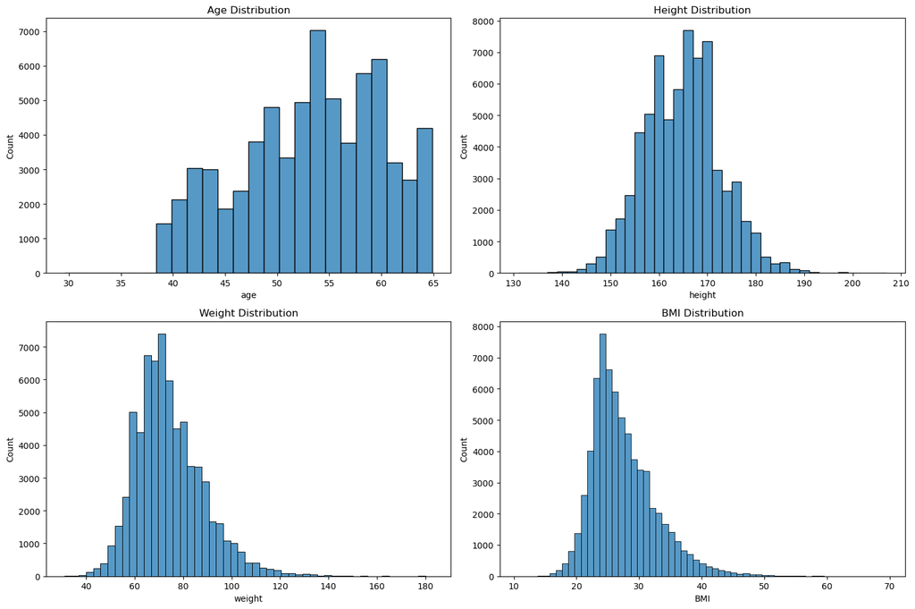

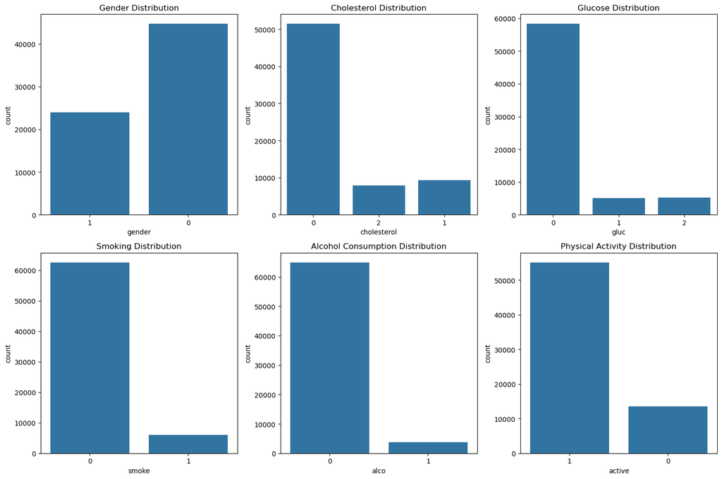

```r
# Create a copy of the cleaned dataset to use for EDA
df <- df

#########################
## Numerical Variables ##
#########################

# Create the layout for the plots
par(mfrow=c(2, 2), mar=c(5, 4, 4, 2) + 0.1, oma=c(0, 0, 2, 0))

# Create histograms for the numerical variables
hist(df$age, breaks=seq(min(df$age), max(df$age) + 1.5, by=1.5), col='lightblue', main='Age Distribution', xlab='Age')

hist(df$height, breaks=seq(min(df$height), max(df$height) + 2, by=2), col='lightblue', main='Height Distribution', xlab='Height')

hist(df$weight, breaks=seq(min(df$weight), max(df$weight) + 3, by=3), col='lightblue', main='Weight Distribution', xlab='Weight')

hist(df$BMI, breaks=seq(min(df$BMI), max(df$BMI) + 1, by=1), col='lightblue', main='BMI Distribution', xlab='BMI')

# Add a title to the plots
mtext("Numeric Variables", outer=TRUE, cex=1.5)

###########################
## Categorical Variables ##
###########################

# Create the layout for the plots
par(mfrow=c(2, 3), mar=c(5, 4, 4, 2) + 0.1, oma=c(0, 0, 2, 0))

# Create bar plots for the categorical variables
barplot(table(df$gender), col='lightblue', main='Gender Distribution', xlab='Gender')

barplot(table(df$cholesterol), col='lightblue', main='Cholesterol Distribution', xlab='Cholesterol')

barplot(table(df$gluc), col='lightblue', main='Glucose Distribution', xlab='Glucose')

barplot(table(df$smoke), col='lightblue', main='Smoking Distribution', xlab='Smoking')

barplot(table(df$alco), col='lightblue', main='Alcohol Consumption Distribution', xlab='Alcohol Consumption')

barplot(table(df$active), col='lightblue', main='Physical Activity Distribution', xlab='Physical Activity')

# Add a title to the plots
mtext("Categorical Variables", outer=TRUE, cex=1.5)
```

Now the distributions by target variable:

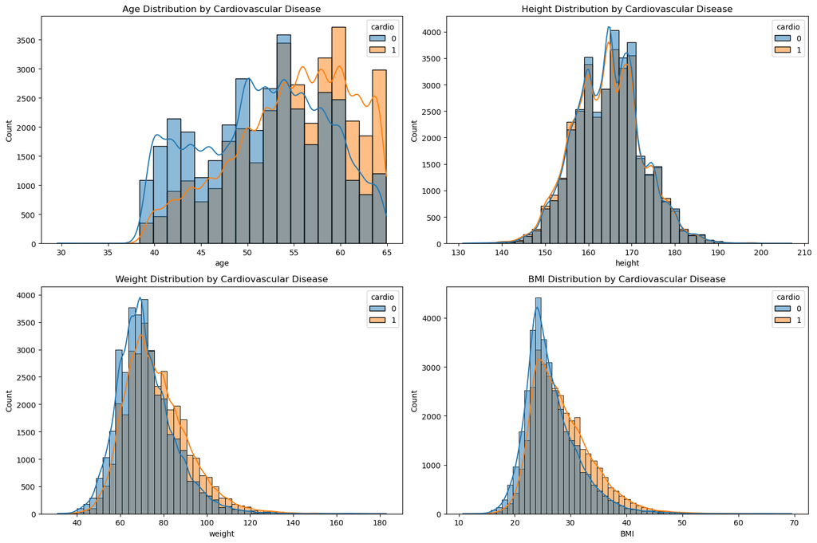

```r
knitr::include_graphics("./numerical_distributions.png")
```

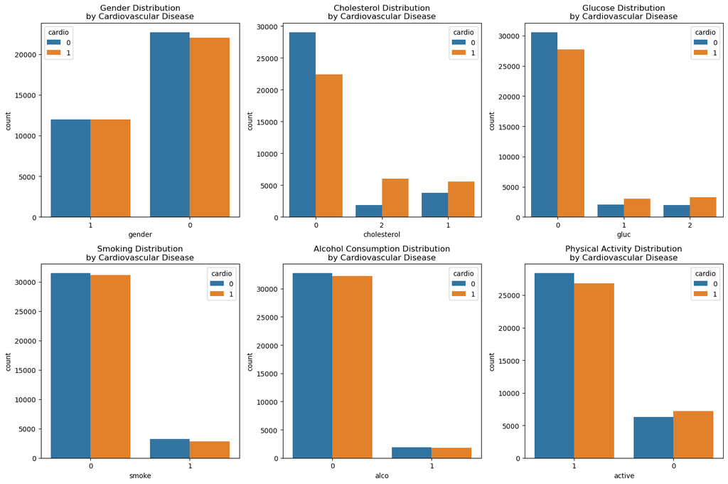

```r
knitr::include_graphics("./categorical_distributions.png")
```

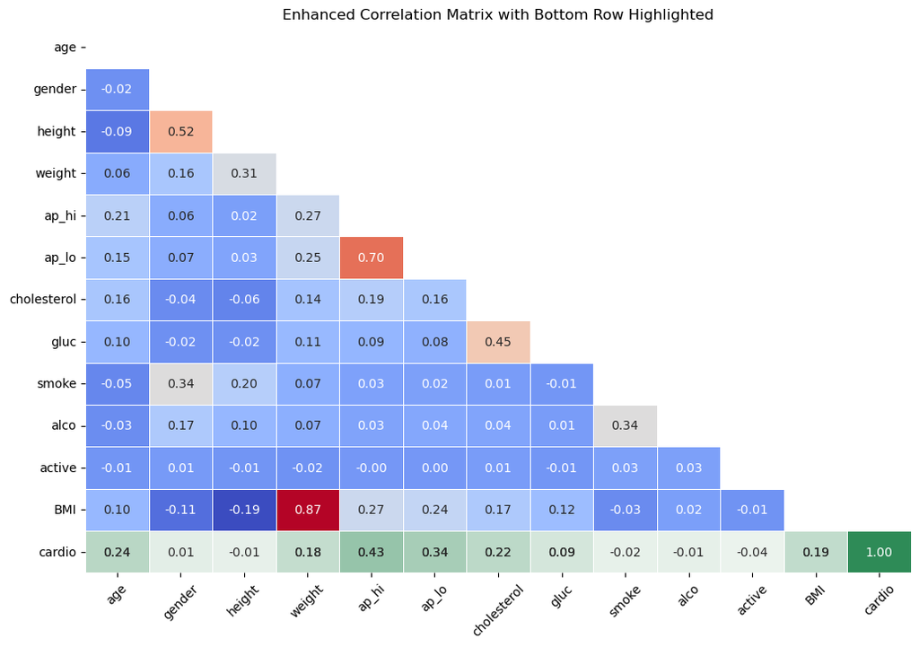

```r
knitr::include_graphics("./heat_matrix.png")
```

```r
########################
## CORRELATION MATRIX ##
########################

# Assuming df is your dataframe
# Filter out non-numeric columns
df_numeric <- df %>% select_if(is.numeric)

# Calculate the correlation matrix on the numeric dataframe
cor_matrix <- cor(df_numeric) %>% as.matrix()

# Create the heatmap
heatmap(cor_matrix,
        Rowv = NA, Colv = NA,
        col = colorRampPalette(c("blue", "white", "red"))(30),
        main = 'Correlation Matrix',
        margins = c(5,5),
        cexRow = 1, cexCol = 1,
        symm = TRUE,
        revC = TRUE)

#######################################################
## DISTRIBUTION OF DATA ACCORDING TO TARGET VARIABLE ##
#######################################################

## Numerical ##

# Create the layout for the plots
par(mfrow=c(3, 3), mar=c(5, 4, 4, 2) + 0.1, oma=c(0, 0, 2, 0))

# Create histograms for the numerical variables
hist(df$age[df$cardio == 0], col='lightblue', main='Age Distribution \n by Cardiovascular Disease (No)', xlab='Age', breaks=seq(min(df$age), max(df$age) + 1.5, by=1.5), xlim=c(min(df$age), max(df$age) + 1.5))

hist(df$age[df$cardio == 1], col='lightcoral', main='Age Distribution \n by Cardiovascular Disease (Yes)', xlab='Age', breaks=seq(min(df$age), max(df$age) + 1.5, by=1.5), xlim=c(min(df$age), max(df$age) + 1.5))

hist(df$height[df$cardio == 0], col='lightblue', main='Height Distribution \n by Cardiovascular Disease (No)', xlab='Height', breaks=seq(min(df$height), max(df$height) + 2, by=2), xlim=c(min(df$height), max(df$height) + 2))

hist(df$height[df$cardio == 1], col='lightcoral', main='Height Distribution \n by Cardiovascular Disease (Yes)', xlab='Height', breaks=seq(min(df$height), max(df$height) + 2, by=2), xlim=c(min(df$height), max(df$height) + 2))

hist(df$weight[df$cardio == 0], col='lightblue', main='Weight Distribution \n by Cardiovascular Disease (No)', xlab='Weight', breaks=seq(min(df$weight), max(df$weight) + 3, by=3), xlim=c(min(df$weight), max(df$weight) + 3))

hist(df$weight[df$cardio == 1], col='lightcoral', main='Weight Distribution \n by Cardiovascular Disease (Yes)', xlab='Weight', breaks=seq(min(df$weight), max(df$weight) + 3, by=3), xlim=c(min(df$weight), max(df$weight) + 3))

hist(df$BMI[df$cardio == 0], col='lightblue', main='BMI Distribution \n by Cardiovascular Disease (No)', xlab='BMI', breaks=seq(min(df$BMI), max(df$BMI) + 1, by=1), xlim=c(min(df$BMI), max(df$BMI) + 1))

hist(df$BMI[df$cardio == 1], col='lightcoral', main='BMI Distribution \n by Cardiovascular Disease (Yes)', xlab='BMI', breaks=seq(min(df$BMI), max(df$BMI) + 1, by=1), xlim=c(min(df$BMI), max(df$BMI) + 1))

# Add a title to the plots
mtext("Numerical Variables", outer=TRUE, cex=1.5)
```

Let’s now checkout the variance inflation factor (VIF) to check for multicollinearity between the numerical variables.

```r
df_vif <- df

# Drop the height column
df_vif <- df_vif %>% select(-height)

no_height <- glm(cardio ~ ., data = df_vif, family = binomial(link = "logit"))

summary(no_height)
```

```
##
## Call:
## glm(formula = cardio ~ ., family = binomial(link = "logit"),
##     data = df_vif)
##
## Coefficients:
##                Estimate Std. Error z value Pr(>|z|)
## (Intercept)  -1.155e+01  1.233e-01 -93.695  < 2e-16 ***
## age           5.135e-02  1.357e-03  37.846  < 2e-16 ***
## gender1      -1.806e-02  2.226e-02  -0.812  0.41703
## weight        6.764e-03  1.454e-03   4.652 3.29e-06 ***
## ap_hi         5.313e-02  8.742e-04  60.777  < 2e-16 ***
## ap_lo         1.678e-02  1.364e-03  12.297  < 2e-16 ***
## cholesterol1  3.812e-01  2.735e-02  13.937  < 2e-16 ***
## cholesterol2  1.093e+00  3.574e-02  30.575  < 2e-16 ***
## gluc1         1.853e-02  3.621e-02   0.512  0.60891
## gluc2        -3.385e-01  3.954e-02  -8.559  < 2e-16 ***
## smoke1       -1.421e-01  3.481e-02  -4.082 4.47e-05 ***
## alco1        -2.065e-01  4.232e-02  -4.879 1.07e-06 ***
## active1      -2.284e-01  2.191e-02 -10.425  < 2e-16 ***
## BMI           1.118e-02  3.994e-03   2.799  0.00513 **
## ---
## Signif. codes:  0 '***' 0.001 '**' 0.01 '*' 0.05 '.' 0.1 ' ' 1
##
## (Dispersion parameter for binomial family taken to be 1)
##
##     Null deviance: 95149  on 68640  degrees of freedom
## Residual deviance: 76972  on 68627  degrees of freedom
## AIC: 77000
##
## Number of Fisher Scoring iterations: 4
```

```r
vif(no_height)
```

```
##                 GVIF Df GVIF^(1/(2*Df))
## age         1.024352  1        1.012103
## gender      1.479077  1        1.216173
## weight      5.136460  1        2.266376
## ap_hi       1.627466  1        1.275722
## ap_lo       1.609946  1        1.268837
## cholesterol 1.497471  2        1.106215
## gluc        1.483226  2        1.103575
## smoke       1.246456  1        1.116448
## alco        1.141193  1        1.068267
## active      1.002659  1        1.001329
## BMI         5.091775  1        2.256496
```

It seems that the collinearity is reasonably low, so we can proceed with the analysis.

# Logistic Regression

## Full model

```r
# Drop the height column and make a copy
df_logi <- df %>% select(-height)

# Fit the logistic regression model
logi_model <- glm(cardio ~ ., data = df_logi, family = binomial(link = "logit"))

# Summary of the model
summary(logi_model)
```

```
##
## Call:
## glm(formula = cardio ~ ., family = binomial(link = "logit"),
##     data = df_logi)
##
## Coefficients:
##                Estimate Std. Error z value Pr(>|z|)
## (Intercept)  -1.155e+01  1.233e-01 -93.695  < 2e-16 ***
## age           5.135e-02  1.357e-03  37.846  < 2e-16 ***
## gender1      -1.806e-02  2.226e-02  -0.812  0.41703
## weight        6.764e-03  1.454e-03   4.652 3.29e-06 ***
## ap_hi         5.313e-02  8.742e-04  60.777  < 2e-16 ***
## ap_lo         1.678e-02  1.364e-03  12.297  < 2e-16 ***
## cholesterol1  3.812e-01  2.735e-02  13.937  < 2e-16 ***
## cholesterol2  1.093e+00  3.574e-02  30.575  < 2e-16 ***
## gluc1         1.853e-02  3.621e-02   0.512  0.60891
## gluc2        -3.385e-01  3.954e-02  -8.559  < 2e-16 ***
## smoke1       -1.421e-01  3.481e-02  -4.082 4.47e-05 ***
## alco1        -2.065e-01  4.232e-02  -4.879 1.07e-06 ***
## active1      -2.284e-01  2.191e-02 -10.425  < 2e-16 ***
## BMI           1.118e-02  3.994e-03   2.799  0.00513 **
## ---
## Signif. codes:  0 '***' 0.001 '**' 0.01 '*' 0.05 '.' 0.1 ' ' 1
##
## (Dispersion parameter for binomial family taken to be 1)
##
##     Null deviance: 95149  on 68640  degrees of freedom
## Residual deviance: 76972  on 68627  degrees of freedom
## AIC: 77000
##
## Number of Fisher Scoring iterations: 4
```

## Nested model

```r
# Drop the gender1 and the gluc1 columns and make a copy
df_logi_2 <- df_logi %>% select(-gender, -gluc)

# Fit the logistic regression model
logi_model_2 <- glm(cardio ~ ., data = df_logi_2, family = binomial(link = "logit"))

# Summary of the model
summary(logi_model_2)
```

```
##
## Call:
## glm(formula = cardio ~ ., family = binomial(link = "logit"),
##     data = df_logi_2)
##
## Coefficients:
##                Estimate Std. Error z value Pr(>|z|)
## (Intercept)  -11.546182   0.123172 -93.741  < 2e-16 ***
## age            0.050991   0.001355  37.643  < 2e-16 ***
## weight         0.006040   0.001282   4.712 2.45e-06 ***
## ap_hi          0.053123   0.000873  60.849  < 2e-16 ***
## ap_lo          0.016836   0.001363  12.351  < 2e-16 ***
## cholesterol1   0.381136   0.026336  14.472  < 2e-16 ***
## cholesterol2   0.943473   0.030648  30.784  < 2e-16 ***
## smoke1        -0.145469   0.033647  -4.323 1.54e-05 ***
## alco1         -0.204348   0.042183  -4.844 1.27e-06 ***
## active1       -0.226596   0.021902 -10.346  < 2e-16 ***
## BMI            0.013028   0.003531   3.690 0.000224 ***
## ---
## Signif. codes:  0 '***' 0.001 '**' 0.01 '*' 0.05 '.' 0.1 ' ' 1
##
## (Dispersion parameter for binomial family taken to be 1)
##
##     Null deviance: 95149  on 68640  degrees of freedom
## Residual deviance: 77048  on 68630  degrees of freedom
## AIC: 77070
##
## Number of Fisher Scoring iterations: 4
```

This model is significantly different than the null one, while every variable is statistically significant.

## Comparison between the full and nested models

```r
# Compare the two models
anova(logi_model, logi_model_2, test = "Chisq")
```

```
## Analysis of Deviance Table
##
## Model 1: cardio ~ age + gender + weight + ap_hi + ap_lo + cholesterol +
##     gluc + smoke + alco + active + BMI
## Model 2: cardio ~ age + weight + ap_hi + ap_lo + cholesterol + smoke +
##     alco + active + BMI
##   Resid. Df Resid. Dev Df Deviance  Pr(>Chi)
## 1     68627      76972
## 2     68630      77048 -3  -75.793 2.449e-16 ***
## ---
## Signif. codes:  0 '***' 0.001 '**' 0.01 '*' 0.05 '.' 0.1 ' ' 1
```

## Tree

### Pre-pruning

We opted for pre-pruning to prevent overfitting. This method is also known as early stopping. It consists in setting stopping criteria as parameter values, allowing the tree to grow until the it meets any of the pre-pruning criteria.

The tested paramaters are the following:

- *cp* or *complexity parameter*, refers to the cost of adding additional variables as splitting nodes
- *min_bucket* refers to the minimum number of samples in a terminal (leaf) node
- *max_depth* refers to the maximum tree height after which the tree stops growing
- *min_split* refers to the minimum number of samples in a node to attempt a split

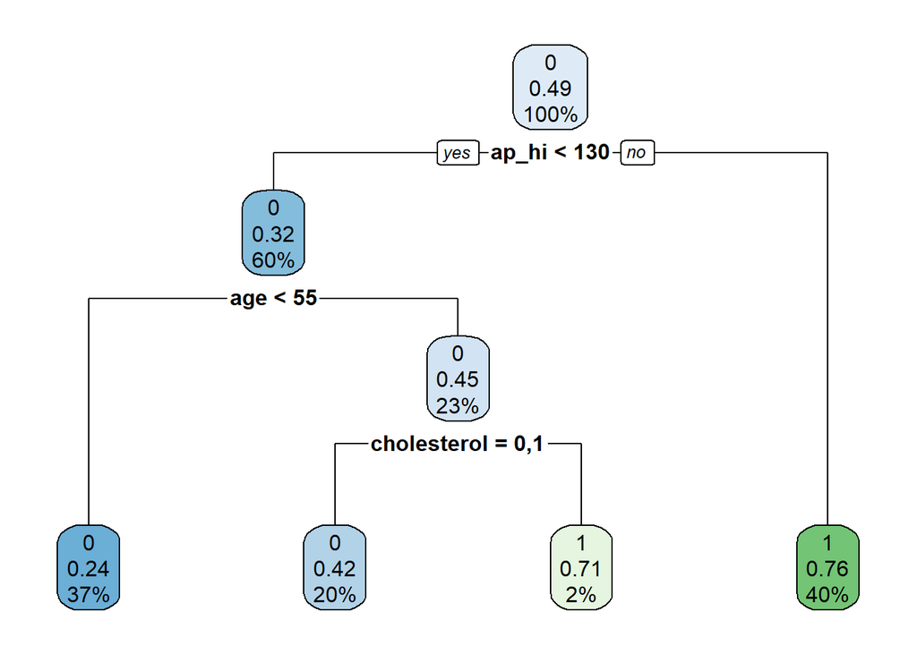

```r
# Create a copy without the excluded variables
df_tree<-df %>% select(-gender, -gluc, -height)

# Perform a train-test split (80/20)
set.seed(42) # For reproducibility

# Set the parameters for the decision tree
cp = c(0.01, 0.001, 0.0001)
minsplit = c(10, 30, 100)
minbucket = c(10, 30, 100)
maxdepth = c(10, 20, 30)

trainIndex <- createDataPartition(df_tree$cardio, p = 0.8, list = FALSE)

df_train <- df_tree[trainIndex, ]

df_test <- df_tree[-trainIndex, ]

# Create a decision tree classifier with parameters adjusted for more branches
dt <- rpart(formula = cardio ~ .,
            data = df_train,
            method = "class",
            control = rpart.control(minsplit = 10,   # Lowered to allow more splits
                                    minbucket = 10,  # Lowered to allow smaller leaf nodes
                                    maxdepth = 10    # Increased to allow deeper trees
                                    ))

# If you want to visualize the tree
rpart.plot(dt)
```

```r
cps = c(0.01, 0.001, 0.0001)
min_buccket = c(10, 30, 100)
max_depth = c(10, 20, 30)
min_split = c(10, 30, 100)
hps = expand.grid(cps=cps, min_buccket=min_buccket, max_depth=max_depth, min_split=min_split, acc=c(-1))
k = 10

set.seed(123)  # Set seed for reproducibility
folds <- createFolds(df_tree$cardio, k = k)

for (i in 1:nrow(hps)) {
  # Initialize vector to store fold errors
  fold_errors <- numeric(10)

  for (fold in 1:k) {
    # Split data into training and validation sets
    train_indices <- unlist(folds[-fold])
    validation_indices <- unlist(folds[fold])
    print(hps[i, 3])
    model = rpart(formula = cardio ~ .,
            data = df_tree[train_indices,],
            method = "class",
            control = rpart.control(maxdepth = hps[i, 3],
                                    minsplit = hps[i, 4],
                                    minbucket = hps[i, 2],
                                    cp = hps[i, 1]))
    test = df_tree[validation_indices, ]
    y_pred = predict(model, test, type="class")
    acc = mean(y_pred == test$cardio)
    hps[i, 5] = acc
  }
}
```

[output not shown]

## Random Forest

```r
# Create a copy of the cleaned dataset to use for feature importance
df_forest <- df_tree

# Perform a train-test split (80/20)
trainIndex <- createDataPartition(df_forest$cardio, p = 0.8, list = FALSE)

df_train <- df_forest[trainIndex, ]
df_test <- df_forest[-trainIndex, ]

# Divide the data into features and target for training
X_train <- df_train[, !(names(df_train) %in% c('cardio'))]
y_train <- df_train$cardio

# Divide the data into features and target for testing
X_test <- df_test[, !(names(df_test) %in% c('cardio'))]
y_test <- df_test$cardio

# Create a random forest classifier
rf <- randomForest(x = X_train, y = y_train, ntree = 500, importance = TRUE, seed = 42)

# Make predictions
y_pred <- predict(rf, X_test)

# Print the confusion matrix
confusionMatrix(y_pred, y_test)
```

```
## Confusion Matrix and Statistics
##
##           Reference
## Prediction    0    1
##          0 5253 2058
##          1 1681 4735
##
##                Accuracy : 0.7276
##                  95% CI : (0.7201, 0.7351)
##     No Information Rate : 0.5051
##     P-Value [Acc > NIR] : < 2.2e-16
##
##                   Kappa : 0.4549
##
##  Mcnemar's Test P-Value : 7.793e-10
##
##             Sensitivity : 0.7576
##             Specificity : 0.6970
##          Pos Pred Value : 0.7185
##          Neg Pred Value : 0.7380
##              Prevalence : 0.5051
##          Detection Rate : 0.3827
##    Detection Prevalence : 0.5326
##       Balanced Accuracy : 0.7273
##
##        'Positive' Class : 0
##
```

```r
# Get the feature importances
feature_importances <- importance(rf)
str(feature_importances)
```

```
##  num [1:9, 1:4] 110 57 287.3 47.2 125.5 ...
##  - attr(*, "dimnames")=List of 2
##   ..$ : chr [1:9] "age" "weight" "ap_hi" "ap_lo" ...
##   ..$ : chr [1:4] "0" "1" "MeanDecreaseAccuracy" "MeanDecreaseGini"
```

```r
print(feature_importances)
```

```
##                      0           1 MeanDecreaseAccuracy MeanDecreaseGini
## age         109.959653  51.4133534            112.05646        5725.9122
## weight       57.037880  27.4180110             83.12110        2928.3893
## ap_hi       287.253884 151.0760020            339.89056        4678.8117
## ap_lo        47.213546  21.5748356             65.65118        2100.1304
## cholesterol 125.461782  36.5674418            127.25295         998.8856
## smoke        16.882929   8.0971794             18.65266         244.8447
## alco         24.326412  -0.5687066             19.22881         193.9807
## active        6.565098  16.8651665             16.58442         340.0295
## BMI          54.293160  32.9911608             83.91484        4294.0931
```

# Logisitc with the most important variable

Let’s try using just the most important variable for the logistic regression and see how it compares to the previously selected model:

```r
df_logi_3 <- df_tree %>% select(cardio, ap_hi)

# Fit the logistic regression model
logi_model_3 <- glm(cardio ~ ., data = df_logi_3, family = binomial(link = "logit"))

# Summary of the model
summary(logi_model_3)
```

```
##
## Call:
## glm(formula = cardio ~ ., family = binomial(link = "logit"),
##     data = df_logi_3)
##
## Coefficients:
##               Estimate Std. Error z value Pr(>|z|)
## (Intercept) -8.6392709  0.0860961 -100.34   <2e-16 ***
## ap_hi        0.0685005  0.0006866   99.77   <2e-16 ***
## ---
## Signif. codes:  0 '***' 0.001 '**' 0.01 '*' 0.05 '.' 0.1 ' ' 1
##
## (Dispersion parameter for binomial family taken to be 1)
##
##     Null deviance: 95149  on 68640  degrees of freedom
## Residual deviance: 80757  on 68639  degrees of freedom
## AIC: 80761
##
## Number of Fisher Scoring iterations: 4
```

## Comparison with the previously selected model

```r
anova(logi_model_2, logi_model_3)
```

```
## Analysis of Deviance Table
##
## Model 1: cardio ~ age + weight + ap_hi + ap_lo + cholesterol + smoke +
##     alco + active + BMI
## Model 2: cardio ~ ap_hi
##   Resid. Df Resid. Dev Df Deviance
## 1     68630      77048
## 2     68639      80757 -9  -3709.1
```

The performance is worse, but the complex model is still much closer to the one variable model than one would expect. Most of the gained precision from the null model is given by the ap_hi feature, confirming the findings of the Random Forest Classifier.